# Text

Amelia McNamara

August 16, 2016

# Overview so far

- On day one, we talked basics of data viz
- Day two was interactivity (in d3)
- Today we’re talking scraping, text, and timelines

# Interactivity in R

- Shiny
- manipulate
- Shiny gadgets

# Getting data from the web

- Application Programming Interfaces (APIs)
- Scraping

We’ll go through some of Scott, Karthik, and Garrett’s [useR tutorial](https://github.com/AmeliaMN/user2016-tutorial/). I’ll flip through the API stuff, and we’ll focus on scraping.

# Scraping!

We’re switching over to the useR tutorial by Scott, Karthik, and Garrett.

See it here: [useR tutorial](https://github.com/AmeliaMN/user2016-tutorial/).

# Some text

# Loading data

(I got the URL right this time– notice it starts with `raw`.)

```r
library(RCurl)
library(readr)
webData <- getURL("https://raw.githubusercontent.com/walkerkq/musiclyrics/master/billboard_lyrics_1964-2015.csv")
lyrics <- read_csv(webData)
dim(lyrics)
```

```
## [1] 5100    6
```

# string manipulations

```r
library(dplyr)
library(stringr)
beatles <- lyrics %>%
  filter(str_detect(Artist, "beatles"))
dim(beatles)
```

```
## [1] 18  6
```

# Now you – find all the songs containing “love”

(How much smaller do you think `love` is than `lyrics`? How much smaller is it really?)

# One approach

```r
love <- lyrics %>%
  filter(str_detect(Lyrics, "lov"))
dim(love)
```

```
## [1] 3032    6
```

# Trump tweets

David Robinson wrote this great [blog post](http://varianceexplained.org/r/trump-tweets/) about Trump’s tweets. It’s also a great walkthrough of some text analysis! We’re going to try it on our own data.

# Words

```r
library(tidytext)
lyricwords <- lyrics %>%
  unnest_tokens(word, Lyrics, token = "words") %>%
  filter(!word %in% stop_words$word,str_detect(word, "[a-z]"))
lyricwords %>%
  select(Song, Artist, word)
```

```
## # A tibble: 579,910 x 3
##           Song                        Artist          word
##          <chr>                         <chr>         <chr>
## 1  wooly bully sam the sham and the pharaohs           sam
## 2  wooly bully sam the sham and the pharaohs          sham
## 3  wooly bully sam the sham and the pharaohs miscellaneous
## 4  wooly bully sam the sham and the pharaohs         wooly
## 5  wooly bully sam the sham and the pharaohs         bully
## 6  wooly bully sam the sham and the pharaohs         wooly
## 7  wooly bully sam the sham and the pharaohs         bully
## 8  wooly bully sam the sham and the pharaohs           sam
## 9  wooly bully sam the sham and the pharaohs          sham
## 10 wooly bully sam the sham and the pharaohs      pharaohs
## # ... with 579,900 more rows
```

# Common words

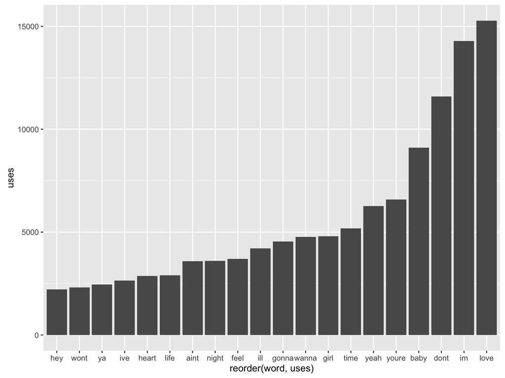

```r
library(ggplot2)
wordcounts <- lyricwords %>%
  group_by(word) %>%
  summarize(uses = n())
wordcounts <- wordcounts %>%
  arrange(desc(uses)) %>%
  slice(1:20)

wordcounts %>%
  ggplot() + geom_bar(aes(x=reorder(word, uses), y=uses),stat = "identity")
```

```r
#  ggplot() + geom_bar(aes(x=word, y=uses),stat = "identity")
```

# Stop words

```r
data(stop_words)
head(stop_words)
```

```
## # A tibble: 6 x 2
##        word lexicon
##       <chr>   <chr>
## 1         a   SMART
## 2       a's   SMART
## 3      able   SMART
## 4     about   SMART
## 5     above   SMART
## 6 according   SMART
```

# We can make our own list of the stop words

```r
morewords <- data.frame(word = c("im", "aint", "dont"), lexicon = "MM")
lyricwords <- lyricwords %>%
  filter(!word %in% morewords$word)
```

# Now you do it– what were the most popular words per year?

What about the most popular by decade?

# One approach

```r
decadelyrics <- lyricwords %>%
  mutate(decade = (Year %/% 10) * 10)
wordcounts <- decadelyrics %>%
  group_by(word, decade) %>%
  summarize(uses = n())

popular <- wordcounts %>%
  group_by(decade) %>%
  slice(which.max(uses))

wordcounts %>%
  arrange(decade, desc(uses))
```

```
## Source: local data frame [69,679 x 3]
## Groups: word [41,335]
##
##     word decade  uses
##    <chr>  <dbl> <int>
## 1   love   1960  1176
## 2   baby   1960   783
## 3   yeah   1960   387
## 4  youre   1960   357
## 5   girl   1960   322
## 6   time   1960   305
## 7    ill   1960   274
## 8  gonna   1960   256
## 9    hey   1960   215
## 10   day   1960   208
## # ... with 69,669 more rows
```

# Sentiment analysis

```r
nrc <- sentiments %>%
  filter(lexicon == "nrc") %>%
  dplyr::select(word, sentiment)
```

```r
years <- lyricwords %>%
  group_by(Year, Song, word) %>%
  mutate(total_words = n()) %>%
  ungroup() %>%
  distinct(Year, word, total_words)
```

```r
by_source_sentiment <- years %>%
  inner_join(nrc, by = "word") %>%
  group_by(Year, sentiment) %>%
  summarize(total = sum(total_words)) %>%
  group_by(Year) %>%
  slice(which.max(total))

by_source_sentiment %>%
  arrange(desc(total))
```

```
## Source: local data frame [51 x 3]
## Groups: Year [51]
##
##     Year sentiment total
##    <int>     <chr> <int>
## 1   2007  positive  1506
## 2   2003  positive  1483
## 3   2002  positive  1429
## 4   2006  positive  1418
## 5   2009  positive  1408
## 6   2010  positive  1354
## 7   2001  positive  1349
## 8   1991  positive  1280
## 9   2004  negative  1236
## 10  2015  positive  1226
## # ... with 41 more rows
```

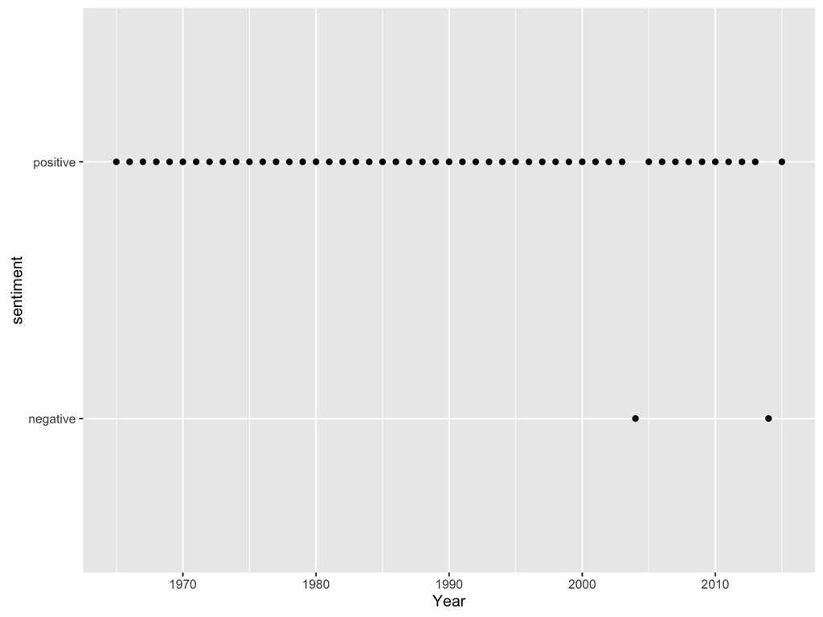

```r
# Doesn't make sense anymore
# by_source_sentiment <- by_source_sentiment %>%
#   mutate(binom = if_else(sentiment =="positive",1,0))

p1 <- ggplot(by_source_sentiment, aes(x=Year, y=sentiment)) + geom_point()
p1
```

```r
# p2 <- ggplot(by_source_sentiment, aes(x=Year, y=binom)) + geom_point() + geom_smooth(aes(y=binom), method="glm", method.args = list(family = "binomial"), se=FALSE, fullrange=TRUE)+xlim(1960, 2040)
# p2
```

# Are songs getting longer or shorter?

# One approach

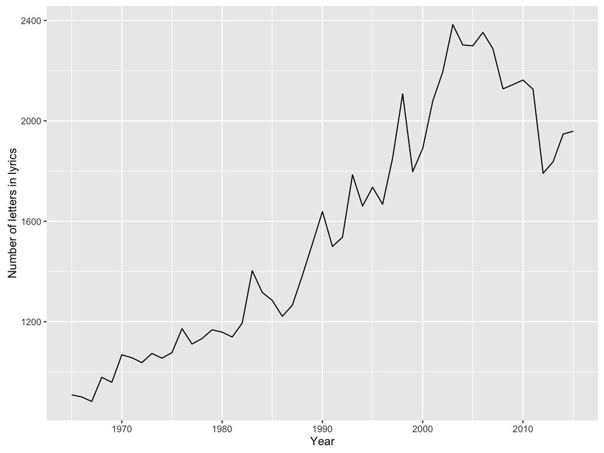

```r
lyrics <- lyrics %>%
  mutate(lyrchar = str_length(Lyrics))

lettery <- lyrics %>%
  group_by(Year) %>%
  summarize(songlength = mean(lyrchar, na.rm=TRUE))
ggplot(lettery) + geom_line(aes(x=Year, y=songlength)) + ylab("Number of letters in lyrics")
```

# Another approach

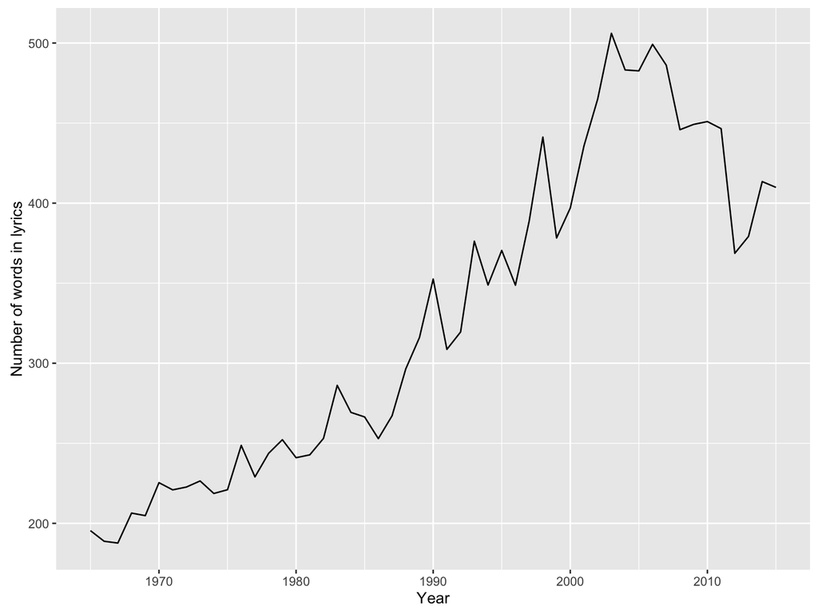

```r
wordy <- lyrics %>%
  unnest_tokens(word, Lyrics, token = "words") %>%
  group_by(Song, Year) %>%
  summarize(length=n()) %>%
  group_by(Year) %>%
  summarize(songlength = mean(length, na.rm=TRUE))
ggplot(wordy) + geom_line(aes(x=Year, y=songlength)) + ylab("Number of words in lyrics")
```

# Repetitive words

```r
repetitive <- lyricwords %>%
  group_by(Artist, Song, word) %>%
  summarize(n=n()) %>%
  arrange(desc(n))
repetitive %>% select(word, n, Song, Artist)
```

```
## Source: local data frame [256,320 x 4]
## Groups: Artist, Song [4,671]
##
##     word     n                          Song
##    <chr> <int>                         <chr>
## 1    dit   180 december 1963 oh what a night
## 2  thoia   156                  thoia thoing
## 3     da   150                   be my lover
## 4    bum   148                     disturbia
## 5     la   141                      la la la
## 6     la   140                        nothin
## 7  shake   138                  shake it off
## 8    bay   136                     a bay bay
## 9     na   132                      la la la
## 10    na   132           gettin jiggy wit it
## # ... with 256,310 more rows, and 1 more variables: Artist <chr>
```

# Vocabulary size

```r
uniques <- lyricwords %>%
  filter(!str_detect(Artist, "featuring")) %>%
  filter(word != "instrumental") %>%
  group_by(Song, Artist) %>%
  summarize(n = length(unique(word))) %>%
  arrange(desc(n))
uniques
```

```
## Source: local data frame [4,161 x 3]
## Groups: Song [3,929]
##
##                   Song                    Artist     n
##                  <chr>                     <chr> <int>
## 1      one more chance         the notorious big   237
## 2        i got 5 on it                     luniz   233
## 3        they want efx                   das efx   232
## 4  deja vu uptown baby lord tariq and peter gunz   229
## 5         oochie wally       nas and bravehearts   227
## 6         american pie                don mclean   219
## 7        ghetto cowboy                  mo thugs   219
## 8  sing for the moment                    eminem   219
## 9            hypnotize         the notorious big   218
## 10             my band                       d12   216
## # ... with 4,151 more rows
```

# Try it with project Gutenberg data

Jordan gave us already-counted words from Project Gutenberg books!

Either: go to a url, like http://www.science.smith.edu/~jcrouser/data/burton-arabian-363.txt and change the `.txt` to `.csv` to download data.

```r
arabian <- read_csv("burton-arabian-363.csv")
```

Or

```r
webData <- getURL("http://www.science.smith.edu/~jcrouser/data/alice.csv")
alice <- read_csv(webData)
```